# Brook Trout Mercury Temperature-Ration Experiments

Matt Fuller

25 July 2025

# 1 Introduction

# 2 Experiment One Analysis

A piecewise regression analysis allows for breakpoint determination. We set up a piecewise regression analysis to find this temperature breakpoint where the slope of the relationship appears to change between the response variable (growth) and the independent variable (temperature).

## 2.1 Data input and review

Data for experiment one contain the following variables:

1. **PIT:** pit tag identifier for each individual fish.
2. **tank:** the experimental tank the individual fish was within for the duration of the experiment.
3. **Hg:** brook trout mercury muscle tissue concentration in ng per g of dry weight.
4. **temperature:** the mean temperature of the water measured in the tank across the duration of the study.
5. **tempfac:** classification for temperature treatments as a factor (16, 18, 20, 22, 24 degrees C).
6. **tot_tank_consumption:** the total mass of food fed to a treatment across the duration of the experiment.
7. **day00massg:** mass (g) of individual fish at the start of the experiment
8. **day24massg:** mass (g) of individual fish at the end of the experiment
9. **conv_eff:** tank-based conversion efficiency for fish (unitless value).
10. **growth_spe:** specific growth rate for individual brook trout calculated as the ((ln(day24massg)-ln(day00massg))/24)*100.

```r
dat_exp1 <- readRDS(file = "./data/temp_ration_experiment1_data.RDS") |>
  mutate(growth_spe = round((log(day24massg)-log(day00massg))/24*100,5))

# save experiment 1 data to csv for viewing in excel if desired
write_csv(dat_exp1, file = "./data/temp_ration_experiment1_data.csv")
```

```r
dat_exp1 |>
  reframe(
    .by = tempfac,
    growth_spe_mean = mean(growth_spe, na.rm = TRUE),
    growth_spe_sd = sd(growth_spe, na.rm = TRUE),
    Hg_mean = mean(Hg, na.rm = TRUE),
    Hg_sd = sd(Hg, na.rm = TRUE),
    end_mass_mean = mean(day24massg, na.rm = TRUE),
    end_mass_sd = sd(day24massg, na.rm = TRUE),
    mass_change_mean = mean(day24massg - day00massg, na.rm = TRUE),
    mass_change_sd = sd(day24massg - day00massg, na.rm = TRUE),
    tot_consumption_g = mean(tot_tank_consumption, na.rm = TRUE),
    conv_eff_mean = mean(conv_eff, na.rm = TRUE),
    n_fish = n()) |>
  pander()
```

Table continues below

| tempfac | growth_spe_mean | growth_spe_sd | Hg_mean | Hg_sd | end_mass_mean |
| --- | --- | --- | --- | --- | --- |
| 16 | 3.188 | 0.4141 | 54.21 | 3.055 | 24.95 |
| 18 | 2.839 | 0.545 | 54.62 | 7.892 | 23.39 |
| 20 | 2.171 | 0.3451 | 56.62 | 7.325 | 20.06 |
| 22 | 0.9659 | 0.7997 | 66.76 | 10.96 | 15.03 |
| 24 | -0.8812 | 0.124 | 86.66 | 4.798 | 9.643 |

Table continues below

| end_mass_sd | mass_change_mean | mass_change_sd | tot_consumption_g |
| --- | --- | --- | --- |
| 4.042 | 13.38 | 2.934 | 86.1 |
| 5.591 | 11.7 | 3.951 | 77.4 |
| 2.359 | 8.157 | 1.686 | 57 |
| 3.92 | 3.263 | 3.22 | 45.8 |
| 2.051 | -2.257 | 0.4962 | 25 |

| conv_eff_mean | n_fish |
| --- | --- |
| 0.43 | 8 |
| 0.4 | 8 |
| 0.35 | 7 |
| 0.21 | 8 |
| -0.93 | 7 |

## 2.2 Correlations

### 2.2.1 Specific Growth and mercury

```r
cor.test(dat_exp1$growth_spe, dat_exp1$Hg, alternative = "two.sided", method = "pearson")
```

```
##
##  Pearson's product-moment correlation
##
## data:  dat_exp1$growth_spe and dat_exp1$Hg
## t = -9.9171, df = 36, p-value = 7.755e-12
## alternative hypothesis: true correlation is not equal to 0
## 95 percent confidence interval:
##  -0.9228584 -0.7376816
## sample estimates:
##        cor
## -0.8555947
```

Correlation between temperature and mercury concentration in the data set.

### 2.2.2 Temperature and mercury

```r
cor.test(dat_exp1$temperature, dat_exp1$Hg, alternative = "two.sided", method = "pearson")
```

```
##
##  Pearson's product-moment correlation
##
## data:  dat_exp1$temperature and dat_exp1$Hg
## t = 6.971, df = 36, p-value = 3.583e-08
## alternative hypothesis: true correlation is not equal to 0
## 95 percent confidence interval:
##  0.5783738 0.8674301
## sample estimates:
##       cor
## 0.7579203
```

### 2.2.3 Specific Growth and Temperature

```r
cor.test(dat_exp1$temperature, dat_exp1$growth_spe, alternative = "two.sided", method = "pearson")
```

```
##
##  Pearson's product-moment correlation
##
## data:  dat_exp1$temperature and dat_exp1$growth_spe
## t = -12.82, df = 36, p-value = 5.526e-15
## alternative hypothesis: true correlation is not equal to 0
## 95 percent confidence interval:
##  -0.9502581 -0.8248629
## sample estimates:
##        cor
## -0.9057141
```

## 2.3 Piecewise regressions

### 2.3.1 Specific Growth-Temperature

Fit the piecewise regression using the ‘segmented’ R package and review its output.

```r
lm_a1_pwise <-
  segmented(lm(growth_spe ~ temperature, data = dat_exp1),
            seg.Z = ~ temperature, psi = list(temperature = c(20)) )

summary(lm_a1_pwise)  # prints summary of piecewise model
```

```
##
##  ***Regression Model with Segmented Relationship(s)***
##
## Call:
## segmented.lm(obj = lm(growth_spe ~ temperature, data = dat_exp1),
##     seg.Z = ~temperature, psi = list(temperature = c(20)))
##
## Estimated Break-Point(s):
##                     Est. St.Err
## psi1.temperature 21.325  0.532
##
## Coefficients of the linear terms:
##                Estimate Std. Error t value Pr(>|t|)
## (Intercept)     6.71881    1.02934   6.527 1.79e-07 ***
## temperature    -0.22427    0.05796  -3.869  0.00047 ***
## U1.temperature -0.70393    0.14364  -4.901       NA
## ---
## Signif. codes:  0 '***' 0.001 '**' 0.01 '*' 0.05 '.' 0.1 ' ' 1
##
## Residual standard error: 0.5053 on 34 degrees of freedom
## Multiple R-Squared: 0.9026,  Adjusted R-squared: 0.894
##
## Boot restarting based on 6 samples. Last fit:
## Convergence attained in 2 iterations (rel. change 5.6574e-10)
```

The “temperature” row shows the coefficient estimate (slope) of the regression line before the breakpoint. The “U1.temperature” row in the coefficient table shows the **change** in the estimate following the breakpoint. To get the slope of the regression model after the breakpoint, add the “U1.temperature” coefficient (-0.7037) to the “temperature” coefficient (-0.2243; baseline slope for reference to other breakpoint slopes), which equals -0.9282. We can also see that using a peicewise regression model improves our explanation of the variability in growth rate values as the adjusted-R<sup>2</sup> value in a simple linear model is 0.8153 and with the piecewise regression it is 0.894.

We can extract the specific breakpoint temperature (and SE) where the model determined the slope change to be between temperature and growth.

**estimated breakpoint temperature:**

```r
(breakpt <- lm_a1_pwise$psi[2])  # grabs estimated breakpoint
```

```
## [1] 21.32453
```

**estimated breakpoint temperature SE:**

```r
(breakptSE <- lm_a1_pwise$psi[3])  # grabs estimated breakpoint SE
```

```
## [1] 0.5323903
```

We can also extract the slopes of each of these two line segments.

```r
segslopes <- slope(lm_a1_pwise) # grabs slopes of two line segments
segslopes$temperature[,"Est."]  # prints the slopes of each line segment
```

```
##   slope1   slope2
## -0.22427 -0.92820
```

If we generate predictions using the new piecewise regression model, we can plot the various segments before and after the breakpoint.

```r
lm_a1_preds <-
  data.frame(growth_spe = predict(lm_a1_pwise,
                              newdata = data.frame(temperature = seq(15,25,0.1))),
             temperature = seq(15,25,0.1))
```

Plot the piecewise regression analysis model fits for comparison.

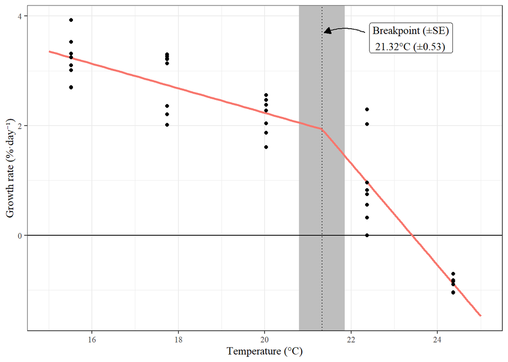

```r
(simp_piece_plot <-
   ggplot(data = dat_exp1,
          aes(x = temperature, y = growth_spe)) +
   annotate(geom = "rect", fill = "grey",
            xmin = breakpt - breakptSE, xmax = breakpt + breakptSE,
            ymin = -Inf, ymax = Inf, alpha = 1) +
   geom_vline(xintercept = breakpt,
              color = "black", linetype = "dotted", linewidth = 0.5) +
   geom_hline(yintercept = 0, color = "black") +
   geom_line(data = lm_a1_preds, aes(x = temperature, y = growth_spe, color = "tomato"),
             linewidth = 1, linetype = "solid") +
   geom_point() +

   # breakpoint line label
   annotate(geom = "curve",
            x=breakpt+1, y=3.7, xend=breakpt+0.05, yend=3.7,
            curvature = 0.2, arrow = arrow(length = unit(0.25,"cm"), type = "closed")) +
   annotate(geom = "label", x=breakpt+1.1, y=3.6, hjust = 0, family = "serif",
            label = paste0("Breakpoint (\u00B1SE)\n ",
                           round(breakpt,2), "\u00B0C (\u00B1",round(breakptSE,2),")") ) +

   theme_bw() +
   scale_x_continuous(breaks = seq(14,26,2)) +
   theme(text = element_text(family = "serif")) +
   labs(x = "Temperature (\u00B0C)",
        y = "Growth rate (%\u00b7day\u207B\u00B9)",) +
   coord_cartesian(xlim = c(15,25)) +
   theme(legend.position = "none")
)
```

```r
# simple linear regression growth of 0 temperature
simlinreg0growth <-
  as.numeric((-1*(lm(growth_spe ~ temperature, data = dat_exp1)$coefficients[1]))/
               lm(growth_spe ~ temperature, data = dat_exp1)$coefficients[2])

# piecewise regression growth of 0 temperature
piecewise0growth <-
  as.numeric((-1*intercept(lm_a1_pwise)$temperature[2])/
               slope(lm_a1_pwise)$temperature[2])
```

The piecewise regression offers some additional information suggesting the slope of the relationship is much steeper (more negative) after warming to 21.32°C. This highlights how growth shifts to negative values at lower temperatures using piecewise regression analysis than when assuming a simple linear relationship. A simple linear regression predicts a transition to negative growth rates at a temperature of 23.78°C, while the piecewise regression predicts a transition to negative growth rates at 23.41°C.

```r
lm_a1_pwise_Growth <-
  piecewise_reg_xtemp(y_var = "growth_spe", dataframe = dat_exp1, init_bkpt = 20,
                    yaxis_txt = "Specific growth rate (%\u00B7day\u207B\u00B9)", label_pos = "tl",
                    family_string = "serif")
```

### 2.3.2 Hg-Temperature

Fit the piecewise regression using Hg as the response variable instead of growth.

```r
lm_a1_pwise_Hg <-
  piecewise_reg_xtemp(y_var = "Hg", dataframe = dat_exp1, init_bkpt = 20,
                    yaxis_txt = "THg (ng\u00b7g\u207B\u00B9)", label_pos = "tl",
                    family_string = "serif")
summary(lm_a1_pwise_Hg$model)
```

```
##
##  ***Regression Model with Segmented Relationship(s)***
##
## Call:
## segmented.lm(obj = lmfit, seg.Z = ~temperature, psi = list(temperature = c(init_bkpt)))
##
## Estimated Break-Point(s):
##                   Est. St.Err
## psi1.temperature 21.4  0.564
##
## Coefficients of the linear terms:
##                Estimate Std. Error t value Pr(>|t|)
## (Intercept)     45.7555    14.8429   3.083  0.00405 **
## temperature      0.5283     0.8358   0.632  0.53161
## U1.temperature   9.4717     2.0713   4.573       NA
## ---
## Signif. codes:  0 '***' 0.001 '**' 0.01 '*' 0.05 '.' 0.1 ' ' 1
##
## Residual standard error: 7.287 on 34 degrees of freedom
## Multiple R-Squared: 0.7524,  Adjusted R-squared: 0.7306
##
## Boot restarting based on 6 samples. Last fit:
## Convergence attained in 3 iterations (rel. change 1.1369e-09)
```

**estimated breakpoint temperature:**

```r
(breakpt <- lm_a1_pwise_Hg$model$psi[2])  # grabs estimated breakpoint
```

```
## [1] 21.40013
```

**estimated breakpoint temperature SE:**

```r
(breakptSE <- lm_a1_pwise_Hg$model$psi[3])  # grabs estimated breakpoint SE
```

```
## [1] 0.5640491
```

We can also extract the slopes of each of these two line segments.

```r
segslopes <- slope(lm_a1_pwise_Hg$model) # grabs slopes of two line segments
segslopes$temperature[,"Est."]  # prints the slopes of each line segment
```

```
##  slope1  slope2
## 0.52825 9.99990
```

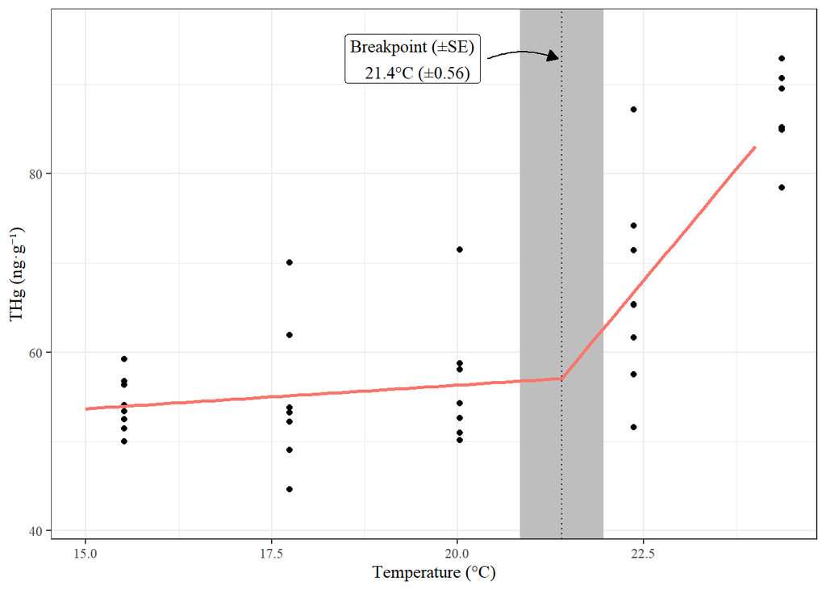

```r
lm_a1_pwise_Hg$fig
```

# 3 Experiment Two Analysis

## 3.1 Data input and review

Data for experiment two contain the following variables:

```r
dat_exp2 <- readRDS(file = "./data/temp_ration_experiment2_data.RDS") |>
  # 30 for 30-day experiment
  mutate(growth_spe = round((log(day30massg)-log(day00massg))/30*100,5)) |>
  # create ranking system for individuals within tanks based on absolute growth
  mutate(.by = tank,
         growth_abs_tnk_rnk = rank(x = (growth_abs*-1), ties.method = "random") ) |>
  # scale the variables used in the SEM analysis
  mutate(growth_abs_tnk_rnk = factor(growth_abs_tnk_rnk, ordered = FALSE),
         temperature_s = as.numeric(scale(temperature)),
         ration_s = as.numeric(scale(ration)),
         growth_abs_s = as.numeric(scale(growth_abs)),
         growth_spe_s = as.numeric(scale(growth_spe)))

# save experiment 2 data to csv for viewing in excel if desired
write_csv(dat_exp2, file = "./data/temp_ration_experiment2_data.csv")
```

```r
fig4_data <- dat_exp2 |>
            mutate(tempLabels = if_else(tempfac == "15","15\u00B0C",
                                        if_else(tempfac == "22", "22\u00B0C", "Time 0"))
                   )|>
            mutate(tempLabels = factor(tempLabels,
                                       levels = c("Time 0","15\u00B0C","22\u00B0C"),
                                       labels = c("Time 0","15\u00B0C","22\u00B0C") )
                   )|>
            select(rationfac, Hg, tempLabels) |>
            # add time 0 data to data set
            add_row(rationfac = factor("T0"), Hg = 95.14, tempLabels = factor("Time 0") ) |>
            add_row(rationfac = factor("T0"), Hg = 82.78, tempLabels = factor("Time 0") ) |>
            add_row(rationfac = factor("T0"), Hg = 92.08, tempLabels = factor("Time 0") ) |>
            add_row(rationfac = factor("T0"), Hg = 115.09, tempLabels = factor("Time 0") ) |>
            add_row(rationfac = factor("T0"), Hg = 124.14, tempLabels = factor("Time 0") ) |>
            add_row(rationfac = factor("T0"), Hg = 88.64, tempLabels = factor("Time 0") ) |>
            add_row(rationfac = factor("T0"), Hg = 90.69, tempLabels = factor("Time 0") ) |>
            add_row(rationfac = factor("T0"), Hg = 91.14, tempLabels = factor("Time 0") ) |>
            add_row(rationfac = factor("T0"), Hg = 89.82, tempLabels = factor("Time 0") ) |>
            add_row(rationfac = factor("T0"), Hg = 107.75, tempLabels = factor("Time 0") ) |>
  mutate(rationfac = factor(rationfac, levels = c("T0","Zero","Low","High")) )
```

**Time 0 Hg concentration summary statistics:**

```r
fig4_data |>
  reframe(.by = tempLabels,
          Hg_mean = mean(Hg, na.rm = TRUE),
          Hg_sd = sd(Hg, na.rm = TRUE),
          n = n()) |>
  filter(tempLabels == "Time 0") |>
  pander()
```

| tempLabels | Hg_mean | Hg_sd | n |
| --- | --- | --- | --- |
| Time 0 | 97.73 | 13.33 | 10 |

**Treatment means and standard deviations in experiment 2::**

```r
dat_exp2 |>
  reframe(
    .by = c(tempfac, rationfac),
    growth_spe_mean = mean(growth_spe, na.rm = TRUE),
    growth_spe_sd = sd(growth_spe, na.rm = TRUE),
    Hg_mean = mean(Hg, na.rm = TRUE),
    Hg_sd = sd(Hg, na.rm = TRUE),
    conv_eff_mean = mean(conv_eff, na.rm = TRUE),
    conv_eff_mean = mean(conv_eff, na.rm = TRUE),
    day30mass_mean = mean(day30massg, na.rm = TRUE),
    day30mass_sd = sd(day30massg, na.rm = TRUE),
    ration_mean = mean(ration),
    n = n()
  ) |>
  mutate(ration_tank_mean = ration_mean * 30) |>
  arrange(tempfac, rationfac) |>
  pander()
```

Table continues below

| tempfac | rationfac | growth_spe_mean | growth_spe_sd | Hg_mean | Hg_sd |
| --- | --- | --- | --- | --- | --- |
| 15 | Zero | -0.45 | 0.0859 | 102.9 | 10.94 |
| 15 | Low | 0.8825 | 0.8057 | 87.95 | 16.6 |
| 15 | High | 1.773 | 0.5917 | 71.38 | 8.014 |
| 22 | Zero | -0.5819 | 0.06806 | 107.8 | 6.212 |
| 22 | Low | 0.1081 | 0.5524 | 91.31 | 13.71 |
| 22 | High | 0.4532 | 0.5328 | 87.61 | 15.06 |

Table continues below

| conv_eff_mean | day30mass_mean | day30mass_sd | ration_mean | n |
| --- | --- | --- | --- | --- |
| NA | 19.83 | 3.703 | 0 | 10 |
| 1.185 | 23.48 | 6.087 | 0.1538 | 20 |
| 1.485 | 32.51 | 9.451 | 0.3208 | 20 |
| NA | 16.43 | 3.593 | 0 | 10 |
| 0.33 | 21.52 | 5.902 | 0.09313 | 20 |
| 0.59 | 24.56 | 6.065 | 0.1877 | 9 |

| ration_tank_mean |
| --- |
| 0 |
| 4.614 |
| 9.625 |
| 0 |
| 2.794 |
| 5.631 |

## 3.2 Correlations

### 3.2.1 Specific Growth vs Hg

```r
cor.test(dat_exp2$Hg, dat_exp2$growth_spe, alternative = "two.sided", method = "pearson")
```

```
##
##  Pearson's product-moment correlation
##
## data:  dat_exp2$Hg and dat_exp2$growth_spe
## t = -15.499, df = 87, p-value < 2.2e-16
## alternative hypothesis: true correlation is not equal to 0
## 95 percent confidence interval:
##  -0.9037921 -0.7894044
## sample estimates:
##        cor
## -0.8568037
```

### 3.2.2 Conv. Eff. vs Hg

```r
cor.test(dat_exp2$conv_eff, dat_exp2$Hg, alternative = "two.sided", method = "pearson")
```

```
##
##  Pearson's product-moment correlation
##
## data:  dat_exp2$conv_eff and dat_exp2$Hg
## t = -3.8862, df = 67, p-value = 0.000236
## alternative hypothesis: true correlation is not equal to 0
## 95 percent confidence interval:
##  -0.6042365 -0.2139273
## sample estimates:
##        cor
## -0.4288922
```

## 3.3 Visualize factored ANOVA data

To visualize this two-way anova, we have a jittered scatter plot overlaid with boxplots to visualize individual data points and their spread along the y-axis for crossed temperature and ration factor levels before fitting the model.

### 3.3.1 Specific Growth response

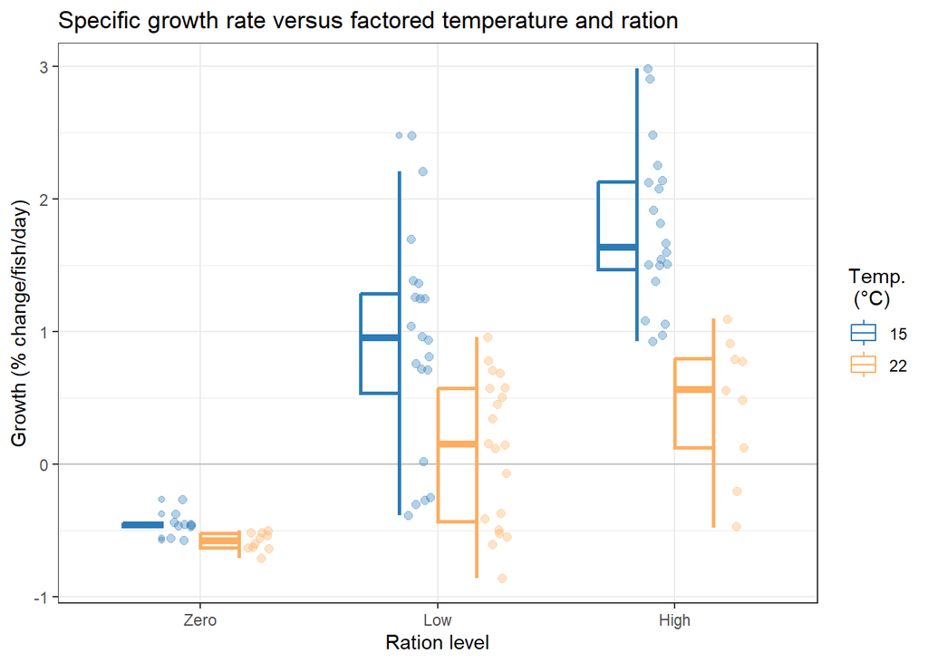

```r
(exp2_growth_anova_plot <-
   ggplot(dat_exp2, aes(x = rationfac,
                        y = growth_spe)) +
   geom_hline(yintercept = 0, color = "grey") +
   ggpol::geom_boxjitter(aes(color = tempfac), alpha = 0.35,
                         jitter.params = list(seed = 1, width = 0.05),
                         width = 0.65,  # spread of boxplot widths
                         size = 0.9,  # line width size
                         jitter.size = 2 ) +  # point size
   theme_bw() +
   scale_color_manual(breaks = c("15","22"),
                      values = c(temp_colors_vec[1],temp_colors_vec[4])) +
   labs(x = "Ration level", y = "Growth (% change/fish/day)",
        color = "Temp.\n (\u00B0C)",
        title = "Specific growth rate versus factored temperature and ration")
)
```

### 3.3.2 Hg response

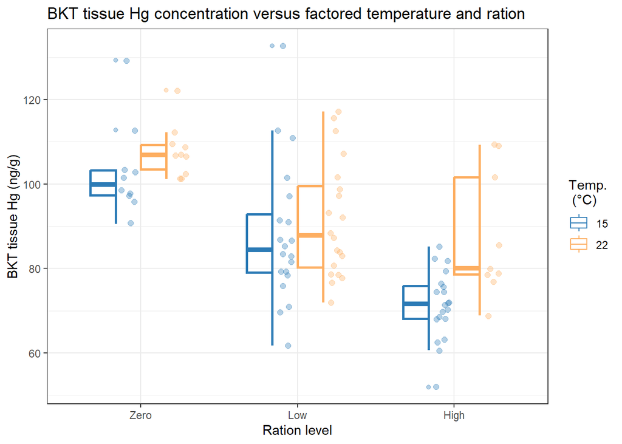

```r
(exp2_Hg_anova_plot <-
   ggplot(dat_exp2, aes(x = rationfac, y = Hg)) +
   ggpol::geom_boxjitter(aes(color = tempfac), alpha = 0.35,
                         jitter.params = list(seed = 1, width = 0.05),
                         width = 0.65,  # spread of boxplot widths
                         size = 0.9,  # line width size
                         jitter.size = 2 ) +  # point size
   theme_bw() +
   scale_color_manual(breaks = c("15","22"),
                      values = c(temp_colors_vec[1],temp_colors_vec[4])) +
   scale_shape_manual(breaks = c("15","22"), values = c(15,16)) +
   labs(x = "Ration level", y = "BKT tissue Hg (ng/g)",
        title = "BKT tissue Hg concentration versus factored temperature and ration",
        color = "Temp.\n (\u00B0C)", shape = "Temp.\n (\u00B0C)")
)
```

## 3.4 Three-way ANOVA

Here we fit a three-way anova using temperature, ration, and ranked individuals from each tank based on their absolute growth during the experiments.

### 3.4.1 Three-way interaction plot

```r
# Calculated 95% confidence intervals for group means & build ggplot data frame
threeway_plot_df <- dat_exp2 |>
  reframe(.by = c(tempfac, rationfac),
          TheMean = mean(Hg, na.rm = TRUE),
          TheSD = sd(Hg, na.rm = TRUE),
          TheSEM = sd(Hg, na.rm = TRUE)/sqrt(n()),
          CIMuliplier = qt(0.95/2 + 0.5, n() - 1),
          N = n()  ) |>
  mutate(LowerBoundCI = TheMean - TheSEM * CIMuliplier,
         UpperBoundCI = TheMean + TheSEM * CIMuliplier,
         LowerBoundSEM = TheMean - TheSEM,
         UpperBoundSEM = TheMean + TheSEM,
         LowerBoundSD = TheMean - TheSD,
         UpperBoundSD = TheMean + TheSD  )
```

Absolute growth ranks range from 1-10. fish with values closer to 1 are faster growing individuals, and fish with ranks closer to 10 are slower growing individuals.

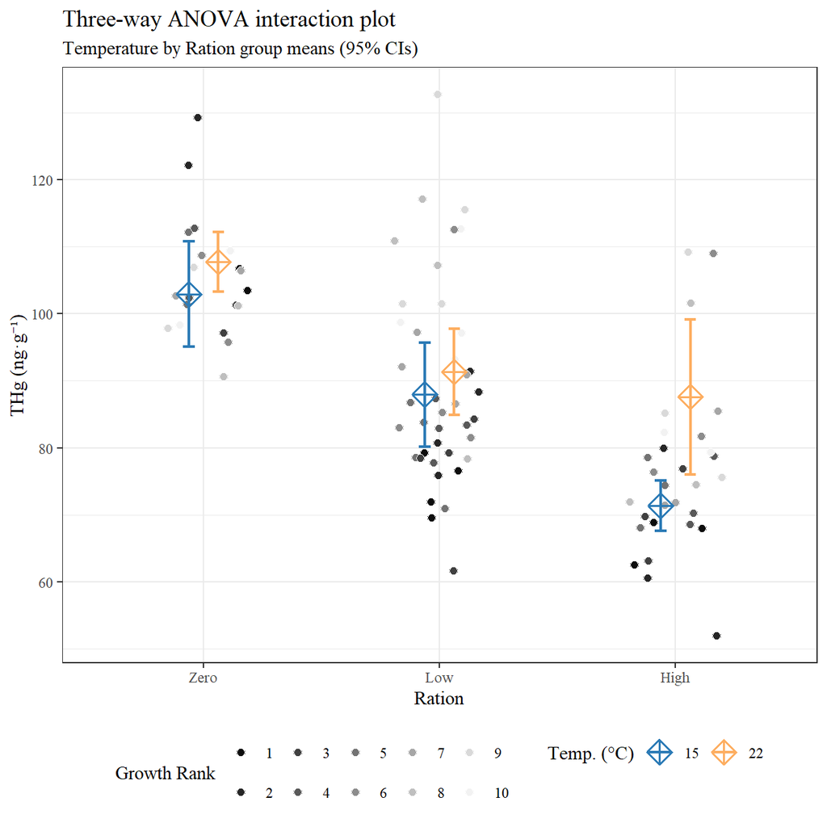

```r
ggplot(data = threeway_plot_df,
       aes(x = rationfac, y = TheMean, color = tempfac)) +

  geom_point(data = select(dat_exp2, TheMean = Hg, rationfac, growth_abs_tnk_rnk, tempfac),
             aes(x = rationfac, y = TheMean, fill = growth_abs_tnk_rnk),
             size = 2, color = "white", shape = 21,
             position = position_jitter(seed = 1, width = 0.2)) +

  geom_errorbar(aes(ymin = LowerBoundCI, color = tempfac, ymax = UpperBoundCI),
                width = 0.1, linewidth = 0.8, position = position_dodge(0.25)) +
  geom_point(position = position_dodge(0.25), shape = 5, size = 4, stroke = 1) +
  geom_point(position = position_dodge(0.25), shape = 3, size = 4, stroke = 1) +

  theme_bw() +
  scale_fill_manual(breaks = (c(1:10)),
                    values = paste0("grey",seq(5,95,length.out = 10))) +
  scale_color_manual(breaks = c("15","18","20","22","24"),
                     values = temp_colors_vec) +
  theme(text = element_text(family = "serif"),
        legend.background = element_blank(),
        legend.position = "bottom",
        legend.position.inside = c(0.8,0.95),
        legend.direction = "horizontal", legend.key = element_blank(),
        plot.caption = element_text(hjust = 0)) +
  labs(x = "Ration", y = "THg (ng\u00b7g\u207B\u00B9)",
       title = "Three-way ANOVA interaction plot",
       subtitle = "Temperature by Ration group means (95% CIs)",
       color = "Temp. (\u00B0C)", fill = "Growth Rank")
```

### 3.4.2 Model fit and summary

```r
# fit the ANOVA model
lm_a2_hg_gwthrnk <-
  aov(Hg ~ tempfac + rationfac + growth_abs_tnk_rnk, data = dat_exp2)
```

**Model results text summary:**

```r
report(lm_a2_hg_gwthrnk)
```

The ANOVA (formula: Hg ~ tempfac + rationfac + growth_abs_tnk_rnk) suggests that:

- The main effect of tempfac is statistically significant and large (F(1, 76) = 19.55, p < .001; Eta2 (partial) = 0.20, 95% CI [0.09, 1.00])
- The main effect of rationfac is statistically significant and large (F(2, 76) = 36.56, p < .001; Eta2 (partial) = 0.49, 95% CI [0.35, 1.00])
- The main effect of growth_abs_tnk_rnk is statistically significant and large (F(9, 76) = 4.44, p < .001; Eta2 (partial) = 0.34, 95% CI [0.15, 1.00])

Effect sizes were labelled following Field’s (2013) recommendations.

**Model results statistics table:**

```r
report_table(lm_a2_hg_gwthrnk)
```

| Parameter | Sum_Squares | df | Mean_Square | F | p | Eta2 (partial) Estimate | Eta2 95% CI low | Eta2 95% CI high |
| --- | --- | --- | --- | --- | --- | --- | --- | --- |
| tempfac | 2350.4187 | 1 | 2350.4187 | 19.5515 | 0 | 0.2046 | 0.0852 | 1 |
| rationfac | 8789.0323 | 2 | 4394.5161 | 36.555 | 0 | 0.4903 | 0.3542 | 1 |
| growth_abs_tnk_rnk | 4809.153 | 9 | 534.3503 | 4.4449 | 0.0001 | 0.3449 | 0.1454 | 1 |
| Residuals | 9136.457 | 76 | 120.2165 |  |  |  |  |  |

Visualize Cohen’s *f* effect size statistics for the model predictors. Cohen suggests that values of 0.10, 0.25, and 0.4 delineate small, medium, and large effect sizes, respectively.

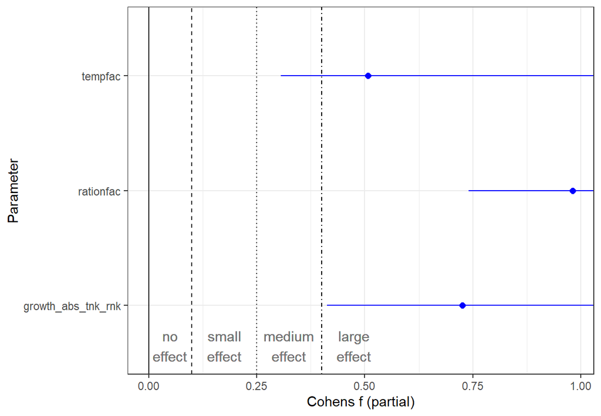

```r
cohens_f(lm_a2_hg_gwthrnk) |>
  # equivalence_test() |>
  plot() +
  theme_bw() +
  geom_vline(xintercept = 0.1, linetype = "dashed") +
  geom_vline(xintercept = 0.25, linetype = "dotted") +
  geom_vline(xintercept = 0.4, linetype = "dotdash") +
  geom_text(aes(x = 0.05, y = 0.65), label = "no\neffect", color = "grey45") +
  geom_text(aes(x = 0.175, y = 0.65), label = "small\neffect", color = "grey45") +
  geom_text(aes(x = 0.325, y = 0.65), label = "medium\neffect", color = "grey45") +
  geom_text(aes(x = 0.475, y = 0.65), label = "large\neffect", color = "grey45")
```

These Cohen’s *f* effect size statistics are in support of the Eta<sup>2</sup> (partial) effect size statistic values from the model statistic table above. They both indicated large effect sizes for each of the three main effects.

Tukey HSD pairwise comparisons.

Pairwise comparisons within a treatment type (i.e., within Temp, Ration, or Absolute Growth Rank).

```r
TukeyHSD(lm_a2_hg_gwthrnk)
```

```
##   Tukey multiple comparisons of means
##     95% family-wise confidence level
##
## Fit: aov(formula = Hg ~ tempfac + rationfac + growth_abs_tnk_rnk, data = dat_exp2)
##
## $tempfac
##           diff      lwr      upr    p adj
## 22-15 10.35739 5.692109 15.02267 3.21e-05
##
## $rationfac
##                diff       lwr        upr     p adj
## Low-Zero  -15.72250 -22.90041  -8.544594 0.0000042
## High-Zero -26.97256 -34.59074 -19.354385 0.0000000
## High-Low  -11.25006 -17.64245  -4.857682 0.0002052
##
## $growth_abs_tnk_rnk
##            diff         lwr       upr     p adj
## 2-1   8.1544444  -8.6926637 25.001553 0.8545882
## 3-1   0.5577778 -16.2893304 17.404886 1.0000000
## 4-1   6.3622222 -10.4848859 23.209330 0.9649002
## 5-1   5.3155556 -11.5315526 22.162664 0.9895348
## 6-1  14.1166667  -2.7304415 30.963775 0.1801860
## 7-1  10.8744444  -5.9726637 27.721553 0.5306170
## 8-1  16.2800000  -0.5671081 33.127108 0.0668479
## 9-1  24.3755556   7.5284474 41.222664 0.0004346
## 10-1 16.9615836  -0.4040180 34.327185 0.0611903
## 3-2  -7.5966667 -24.4437748  9.250441 0.8997017
## 4-2  -1.7922222 -18.6393304 15.054886 0.9999986
## 5-2  -2.8388889 -19.6859970 14.008219 0.9999245
## 6-2   5.9622222 -10.8848859 22.809330 0.9769869
## 7-2   2.7200000 -14.1271081 19.567108 0.9999474
## 8-2   8.1255556  -8.7215526 24.972664 0.8571662
## 9-2  16.2211111  -0.6259970 33.068219 0.0688476
## 10-2  8.8071391  -8.5584625 26.172741 0.8173509
## 4-3   5.8044444 -11.0426637 22.651553 0.9807689
## 5-3   4.7577778 -12.0893304 21.604886 0.9953185
## 6-3  13.5588889  -3.2882192 30.405997 0.2251675
## 7-3  10.3166667  -6.5304415 27.163775 0.6044080
## 8-3  15.7222222  -1.1248859 32.569330 0.0879069
## 9-3  23.8177778   6.9706696 40.664886 0.0006462
## 10-3 16.4038058  -0.9617958 33.769407 0.0801146
## 5-4  -1.0466667 -17.8937748 15.800441 1.0000000
## 6-4   7.7544444  -9.0926637 24.601553 0.8879485
## 7-4   4.5122222 -12.3348859 21.359330 0.9968541
## 8-4   9.9177778  -6.9293304 26.764886 0.6564946
## 9-4  18.0133333   1.1662252 34.860441 0.0265613
## 10-4 10.5993613  -6.7662402 27.964963 0.6088591
## 6-5   8.8011111  -8.0459970 25.648219 0.7904374
## 7-5   5.5588889 -11.2882192 22.405997 0.9856866
## 8-5  10.9644444  -5.8826637 27.811553 0.5187581
## 9-5  19.0600000   2.2128919 35.907108 0.0145046
## 10-5 11.6460280  -5.7195736 29.011630 0.4752068
## 7-6  -3.2422222 -20.0893304 13.604886 0.9997718
## 8-6   2.1633333 -14.6837748 19.010441 0.9999926
## 9-6  10.2588889  -6.5882192 27.105997 0.6120188
## 10-6  2.8449169 -14.5206847 20.210518 0.9999405
## 8-7   5.4055556 -11.4415526 22.252664 0.9882205
## 9-7  13.5011111  -3.3459970 30.348219 0.2302351
## 10-7  6.0871391 -11.2784625 23.452741 0.9784088
## 9-8   8.0955556  -8.7515526 24.942664 0.8598160
## 10-8  0.6815836 -16.6840180 18.047185 1.0000000
## 10-9 -7.4139720 -24.7795736  9.951630 0.9261556
```

Pairwise comparisons among growth rank levels for each Temperature-Ration factor level cross.

```r
# pair-wise comparisons among factor levels for each contrasting fixed effect
pairs(emmeans(lm_a2_hg_gwthrnk, ~rationfac | tempfac |  growth_abs_tnk_rnk))
```

```
## tempfac = 15, growth_abs_tnk_rnk = 1:
##  contrast    estimate   SE df t.ratio p.value
##  Zero - Low      15.7 3.00 76   5.236  <.0001
##  Zero - High     27.2 3.22 76   8.456  <.0001
##  Low - High      11.5 2.72 76   4.243  0.0002
##
## tempfac = 22, growth_abs_tnk_rnk = 1:
##  contrast    estimate   SE df t.ratio p.value
##  Zero - Low      15.7 3.00 76   5.236  <.0001
##  Zero - High     27.2 3.22 76   8.456  <.0001
##  Low - High      11.5 2.72 76   4.243  0.0002
##
## tempfac = 15, growth_abs_tnk_rnk = 2:
##  contrast    estimate   SE df t.ratio p.value
##  Zero - Low      15.7 3.00 76   5.236  <.0001
##  Zero - High     27.2 3.22 76   8.456  <.0001
##  Low - High      11.5 2.72 76   4.243  0.0002
##
## tempfac = 22, growth_abs_tnk_rnk = 2:
##  contrast    estimate   SE df t.ratio p.value
##  Zero - Low      15.7 3.00 76   5.236  <.0001
##  Zero - High     27.2 3.22 76   8.456  <.0001
##  Low - High      11.5 2.72 76   4.243  0.0002
##
## tempfac = 15, growth_abs_tnk_rnk = 3:
##  contrast    estimate   SE df t.ratio p.value
##  Zero - Low      15.7 3.00 76   5.236  <.0001
##  Zero - High     27.2 3.22 76   8.456  <.0001
##  Low - High      11.5 2.72 76   4.243  0.0002
##
## tempfac = 22, growth_abs_tnk_rnk = 3:
##  contrast    estimate   SE df t.ratio p.value
##  Zero - Low      15.7 3.00 76   5.236  <.0001
##  Zero - High     27.2 3.22 76   8.456  <.0001
##  Low - High      11.5 2.72 76   4.243  0.0002
##
## tempfac = 15, growth_abs_tnk_rnk = 4:
##  contrast    estimate   SE df t.ratio p.value
##  Zero - Low      15.7 3.00 76   5.236  <.0001
##  Zero - High     27.2 3.22 76   8.456  <.0001
```

[output cut: 66 more lines]

```
##  Low - High      11.5 2.72 76   4.243  0.0002
##
## tempfac = 15, growth_abs_tnk_rnk = 10:
##  contrast    estimate   SE df t.ratio p.value
##  Zero - Low      15.7 3.00 76   5.236  <.0001
##  Zero - High     27.2 3.22 76   8.456  <.0001
##  Low - High      11.5 2.72 76   4.243  0.0002
##
## tempfac = 22, growth_abs_tnk_rnk = 10:
##  contrast    estimate   SE df t.ratio p.value
##  Zero - Low      15.7 3.00 76   5.236  <.0001
##  Zero - High     27.2 3.22 76   8.456  <.0001
##  Low - High      11.5 2.72 76   4.243  0.0002
##
## P value adjustment: tukey method for comparing a family of 3 estimates
```

## 3.5 SEM

For the SEM analysis, we explored model fits using continuous data for Ration, Temperature, and Absolute Growth as explanatory variables of Hg. All variables were also standardized with a mean of 0 and standard deviation of 1. This means the path coefficients in the path diagrams are directly comparable in magnitude for their given explanatory power when explaining variance in the model.

### 3.5.1 Ration: zero, low, & high treatments

#### 3.5.1.1 Model fit

```r
form_00_cont <- '
Hg ~ growth_abs_s + temperature_s + ration_s
growth_abs_s ~ temperature_s + ration_s
'

sem_00_cont <- lavaan::sem(form_00_cont,
                      cluster = "growth_abs_tnk_rnk",
                      std.ov = TRUE,  # TRUE = formula has standardized predictors
                      data = dat_exp2
                      )
```

#### 3.5.1.2 Model diagnostics

Model fit statistics:

```r
# model fit statistics and their interpretation
effectsize::interpret(sem_00_cont)
```

```
##     Name      Value Threshold Interpretation
## 1    GFI 1.0000e+00      0.95   satisfactory
## 2   AGFI 1.0000e+00      0.90   satisfactory
## 3    NFI 1.0000e+00      0.90   satisfactory
## 4   NNFI 1.0000e+00      0.90   satisfactory
## 5    CFI 1.0000e+00      0.90   satisfactory
## 6  RMSEA 0.0000e+00      0.05   satisfactory
## 7   SRMR 6.7987e-17      0.08   satisfactory
## 8    RFI 1.0000e+00      0.90   satisfactory
## 9   PNFI 0.0000e+00      0.50           poor
## 10   IFI 1.0000e+00      0.90   satisfactory
```

Satisfactory goodness of fit statistics here indicates the model fits the data well and supports drawing conclusions from the path diagram.

Summary of model output:

```r
summary(sem_00_cont)
```

```
## lavaan 0.6-19 ended normally after 1 iteration
##
##   Estimator                                         ML
##   Optimization method                           NLMINB
##   Number of model parameters                         9
##
##   Number of observations                            89
##   Number of clusters [growth_abs_tnk_rnk]           10
##
## Model Test User Model:
##                                               Standard      Scaled
##   Test Statistic                                 0.000       0.000
##   Degrees of freedom                                 0           0
##
## Parameter Estimates:
##
##   Standard errors                        Robust.cluster
##   Information                                  Observed
##   Observed information based on                 Hessian
##
## Regressions:
##                    Estimate  Std.Err  z-value  P(>|z|)
##   Hg ~
##     growth_abs_s     -0.808    0.131   -6.155    0.000
##     temperature_s    -0.094    0.079   -1.194    0.232
##     ration_s         -0.071    0.142   -0.502    0.615
##   growth_abs_s ~
##     temperature_s    -0.131    0.027   -4.772    0.000
##     ration_s          0.742    0.079    9.448    0.000
##
## Intercepts:
##                    Estimate  Std.Err  z-value  P(>|z|)
##    .Hg               -0.000    0.077   -0.000    1.000
##    .growth_abs_s     -0.000    0.159   -0.000    1.000
##
## Variances:
##                    Estimate  Std.Err  z-value  P(>|z|)
##    .Hg                0.312    0.054    5.748    0.000
##    .growth_abs_s      0.343    0.092    3.726    0.000
```

#### 3.5.1.3 Path diagram

```r
labs_00_cont = list(temperature_s = "Water\nTemp.(\u00B0C)",
                    ration_s = "Food ration\n(g\u00b7fish\u207B\u00B9\u00b7day\u207B\u00B9)",
                    growth_abs_s = "Absolute BKT\ngrowth (g)",
                    Hg = "BKT THg\n(ng\u00b7g\u207B\u00B9)"
                 )

(pd_3rationfac <-
  lavaanPlot(model = sem_00_cont,
           coef = TRUE,
           stars = "regress",
           # stand = TRUE,
           labels = labs_00_cont,
           graph_options = list(rankdir = 'BT',
                                labelloc = "t",
                                overlap = TRUE,
                                fontsize = 36,
                                layout = 'dot')) )
```

[interactive chart not shown]

```r
# save grViz object to png file
pd_3rationfac |> export_svg() |> charToRaw() |>
  rsvg_png("./figs/Figure6A_SEM_zero_low_high.png", width = 1080, height = 1080)
```

### 3.5.2 Ration: low & high treatments

#### 3.5.2.1 Model fit

```r
sem_01_cont <- lavaan::sem(form_00_cont,
                      cluster = "growth_abs_tnk_rnk",
                      std.ov = TRUE,  # TRUE = formula has standardized predictors
                      data = dat_exp2 |> filter(rationfac != "Zero")
                      )
```

#### 3.5.2.2 Model diagnostics

Model fit statistics:

```r
# model fit statistics and their interpretation
effectsize::interpret(sem_01_cont)
```

```
##     Name        Value Threshold Interpretation
## 1    GFI 1.000000e+00      0.95   satisfactory
## 2   AGFI 1.000000e+00      0.90   satisfactory
## 3    NFI 1.000000e+00      0.90   satisfactory
## 4   NNFI 1.000000e+00      0.90   satisfactory
## 5    CFI 1.000000e+00      0.90   satisfactory
## 6  RMSEA 0.000000e+00      0.05   satisfactory
## 7   SRMR 8.799268e-17      0.08   satisfactory
## 8    RFI 1.000000e+00      0.90   satisfactory
## 9   PNFI 0.000000e+00      0.50           poor
## 10   IFI 1.000000e+00      0.90   satisfactory
```

Satisfactory goodness of fit statistics here indicates the model fits the data well and supports drawing conclusions from the path diagram.

Summary of model output:

```r
summary(sem_01_cont)
```

```
## lavaan 0.6-19 ended normally after 1 iteration
##
##   Estimator                                         ML
##   Optimization method                           NLMINB
##   Number of model parameters                         9
##
##   Number of observations                            69
##   Number of clusters [growth_abs_tnk_rnk]           10
##
## Model Test User Model:
##                                               Standard      Scaled
##   Test Statistic                                 0.000       0.000
##   Degrees of freedom                                 0           0
##
## Parameter Estimates:
##
##   Standard errors                        Robust.cluster
##   Information                                  Observed
##   Observed information based on                 Hessian
##
## Regressions:
##                    Estimate  Std.Err  z-value  P(>|z|)
##   Hg ~
##     growth_abs_s     -0.880    0.148   -5.959    0.000
##     temperature_s    -0.168    0.097   -1.730    0.084
##     ration_s         -0.014    0.131   -0.110    0.913
##   growth_abs_s ~
##     temperature_s    -0.197    0.052   -3.757    0.000
##     ration_s          0.723    0.064   11.306    0.000
##
## Intercepts:
##                    Estimate  Std.Err  z-value  P(>|z|)
##    .Hg               -0.001    0.115   -0.005    0.996
##    .growth_abs_s     -0.280    0.190   -1.473    0.141
##
## Variances:
##                    Estimate  Std.Err  z-value  P(>|z|)
##    .Hg                0.347    0.074    4.686    0.000
##    .growth_abs_s      0.470    0.129    3.661    0.000
```

#### 3.5.2.3 Path diagram

```r
(pd_2rationfac <-
  lavaanPlot(model = sem_01_cont,
           coef = TRUE,
           stars = "regress",
           labels = labs_00_cont,
           graph_options = list(rankdir = 'BT',
                                labelloc = "t",
                                overlap = TRUE,
                                fontsize = 36,
                                layout = 'dot')) )
```

[interactive chart not shown]

```r
# save grViz object to png file
pd_2rationfac |> export_svg() |> charToRaw() |>
  rsvg_png("./figs/Figure6B_SEM_low_high.png", width = 1080, height = 1080)
```

# 4 Manuscript Table 1

Experiment 1 portion of table.

```r
msTable1_exp1 <- dat_exp1 |>
  reframe(
    .by = tempfac,
    growth_spe_mean = round(mean(growth_spe, na.rm = TRUE),1),
    growth_spe_sd = round(sd(growth_spe, na.rm = TRUE),1),
    Hg_mean = round(mean(Hg, na.rm = TRUE),1),
    Hg_sd = round(sd(Hg, na.rm = TRUE),1),
    tot_consumption_g = round(mean(tot_tank_consumption, na.rm = TRUE),1),
    conv_eff_mean = round(mean(conv_eff, na.rm = TRUE),1)) |>
  mutate(ration = NA,
         growth_spe = paste0(growth_spe_mean,"\u00B1",growth_spe_sd),
         Hg = paste0(Hg_mean,"\u00B1",Hg_sd),
         Experiment = 1) |>
  select(Experiment, tempfac, ration, growth_spe, Hg, tot_consumption_g, conv_eff_mean)
```

Experiment 2 portion of table.

```r
msTable1_exp2_T0 <- fig4_data |>
  reframe(.by = tempLabels,
          Hg_mean = round(mean(Hg, na.rm = TRUE),1),
          Hg_sd = round(sd(Hg, na.rm = TRUE),1) ) |>
  filter(tempLabels == "Time 0") |>
  mutate(tempfac = factor("Time 0", levels = c("Time 0","15","22")),
         ration = NA,
         growth_spe = NA,
         Hg = paste0(Hg_mean,"\u00B1",Hg_sd),
         tot_consumption_g = NA,
         conv_eff_mean = NA) |>
  select(-tempLabels, -Hg_mean, -Hg_sd)

msTable1_exp2 <- dat_exp2 |>
  reframe(
    .by = c(tempfac, rationfac),
    growth_spe_mean = round(mean(growth_spe, na.rm = TRUE),1),
    growth_spe_sd = round(sd(growth_spe, na.rm = TRUE),1),
    Hg_mean = round(mean(Hg, na.rm = TRUE),1),
    Hg_sd = round(sd(Hg, na.rm = TRUE),1),
    ration_mean = mean(ration),
    conv_eff_mean = if_else(is.nan(mean(conv_eff, na.rm = TRUE)),
                            NA,
                            round(mean(conv_eff, na.rm = TRUE),1))) |>
  mutate(ration = NA,
         growth_spe = paste0(growth_spe_mean,"\u00B1",growth_spe_sd),
         Hg = paste0(Hg_mean,"\u00B1",Hg_sd),
         ration_tank_mean = ration_mean * 30) |>
  select(tempfac, ration = rationfac, growth_spe, Hg, tot_consumption_g = ration_tank_mean,
         conv_eff_mean) |>
  bind_rows(msTable1_exp2_T0) |>
  mutate(tempfac = factor(tempfac, levels = c("Time 0","15","22")),
         Experiment = 2,
         # update total consumption to an average tank/treatment total to match exp1
         tot_consumption_g = if_else(tempfac == "22" & ration == "High",
                                     tot_consumption_g * 9,  # one mortailty so 9 fish
                                     tot_consumption_g * 10) # 10 fish per tank
         ) |>
  relocate(Experiment) |>
  arrange(tempfac, ration)
```

Join Experiment 1 and Experiment 2 into single table and adjust some formatting.

```r
msTable1 <- bind_rows(msTable1_exp1, msTable1_exp2) |>
  mutate(tot_consumption_g = round(tot_consumption_g,1)) |>
  mutate(across(everything(), ~as.character(.x))) |>
  mutate(across(everything(), ~replace_na(.x, "*"))) |>
  rename(Temperature = tempfac, Ration = ration, `Specific Growth` = growth_spe,
         `Total Consumption` = tot_consumption_g, `Conversion Efficiency` = conv_eff_mean)
```

**View Table 1:**

Table continues below

| Experiment | Temperature | Ration | Specific Growth | Hg |
| --- | --- | --- | --- | --- |
| 1 | 16 | * | 3.2±0.4 | 54.2±3.1 |
| 1 | 18 | * | 2.8±0.5 | 54.6±7.9 |
| 1 | 20 | * | 2.2±0.3 | 56.6±7.3 |
| 1 | 22 | * | 1±0.8 | 66.8±11 |
| 1 | 24 | * | -0.9±0.1 | 86.7±4.8 |
| 2 | Time 0 | * | * | 97.7±13.3 |
| 2 | 15 | Zero | -0.5±0.1 | 102.9±10.9 |
| 2 | 15 | Low | 0.9±0.8 | 87.9±16.6 |
| 2 | 15 | High | 1.8±0.6 | 71.4±8 |
| 2 | 22 | Zero | -0.6±0.1 | 107.8±6.2 |
| 2 | 22 | Low | 0.1±0.6 | 91.3±13.7 |
| 2 | 22 | High | 0.5±0.5 | 87.6±15.1 |

| Total Consumption | Conversion Efficiency |
| --- | --- |
| 86.1 | 0.4 |
| 77.4 | 0.4 |
| 57 | 0.3 |
| 45.8 | 0.2 |
| 25 | -0.9 |
| * | * |
| 0 | * |
| 46.1 | 1.2 |
| 96.2 | 1.5 |
| 0 | * |
| 27.9 | 0.3 |
| 50.7 | 0.6 |

Save Table 1 to file.

```r
write_csv(msTable1, file = "./tables/msTable1.csv")
```

# 5 Manuscript Figures

## 5.1 Figure 1

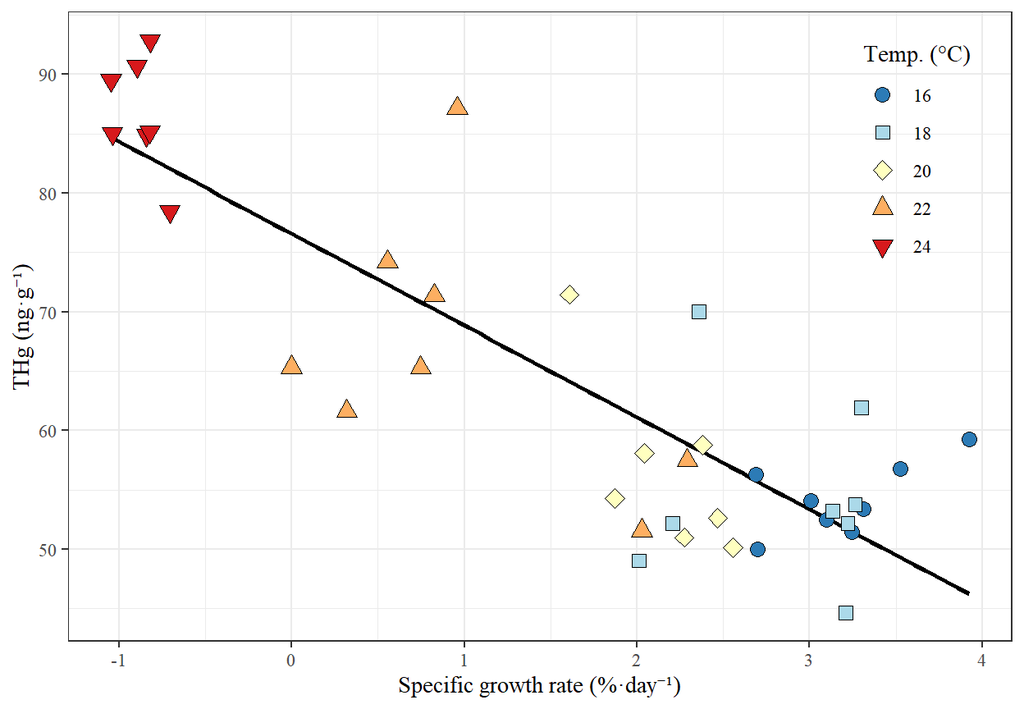

```r
(msFig1 <-
   ggplot(data = dat_exp1, aes(x = growth_spe, y = Hg,)) +
   geom_smooth(method = "lm", formula = 'y ~ x', se = FALSE, color = "black") +
   geom_point(aes(shape = tempfac, fill = tempfac),
              size = 3) +
   theme_bw() +
   scale_shape_manual(breaks = c("16","18","20","22","24"),
                      values = c(21,22,23,24,25)) +
   scale_fill_manual(breaks = c("16","18","20","22","24"),
                      values = temp_colors_vec ) +
   theme(text = element_text(family = "serif"),
         legend.position = "inside", legend.position.inside = c(0.9,0.775),
         legend.background = element_blank(), legend.key = element_blank()) +
   labs(x = "Specific growth rate (%\u00B7day\u207B\u00B9)", y = "THg (ng\u00B7g\u207B\u00B9)",
        shape = "Temp. (\u00B0C)", fill = "Temp. (\u00B0C)")
)
```

**Linear model fit report:**

```r
report(lm(Hg ~ growth_spe, data = dat_exp1))
```

We fitted a linear model (estimated using OLS) to predict Hg with growth_spe (formula: Hg ~ growth_spe). The model explains a statistically significant and substantial proportion of variance (R2 = 0.73, F(1, 36) = 98.35, p < .001, adj. R2 = 0.72). The model’s intercept, corresponding to growth_spe = 0, is at 76.59 (95% CI [72.96, 80.22], t(36) = 42.76, p < .001). Within this model:

- The effect of growth spe is statistically significant and negative (beta = -7.74, 95% CI [-9.32, -6.16], t(36) = -9.92, p < .001; Std. beta = -0.86, 95% CI [-1.03, -0.68])

Standardized parameters were obtained by fitting the model on a standardized version of the dataset. 95% Confidence Intervals (CIs) and p-values were computed using a Wald t-distribution approximation.

**Linear model estimate table:**

```r
report_table(lm(Hg ~ growth_spe, data = dat_exp1))
```

```
## Parameter   | Coefficient |         95% CI | t(36) |      p | Std. Coef.
## ------------------------------------------------------------------------
## (Intercept) |       76.59 | [72.96, 80.22] | 42.76 | < .001 |   1.13e-16
## growth spe  |       -7.74 | [-9.32, -6.16] | -9.92 | < .001 |      -0.86
##             |             |                |       |        |
## AIC         |             |                |       |        |
## AICc        |             |                |       |        |
## BIC         |             |                |       |        |
## R2          |             |                |       |        |
## R2 (adj.)   |             |                |       |        |
## Sigma       |             |                |       |        |
##
## Parameter   | Std. Coef. 95% CI |    Fit
## ----------------------------------------
## (Intercept) |    [-0.17,  0.17] |
## growth spe  |    [-1.03, -0.68] |
##             |                   |
## AIC         |                   | 263.57
## AICc        |                   | 264.27
## BIC         |                   | 268.48
## R2          |                   |   0.73
## R2 (adj.)   |                   |   0.72
## Sigma       |                   |   7.37
```

## 5.2 Figure 2

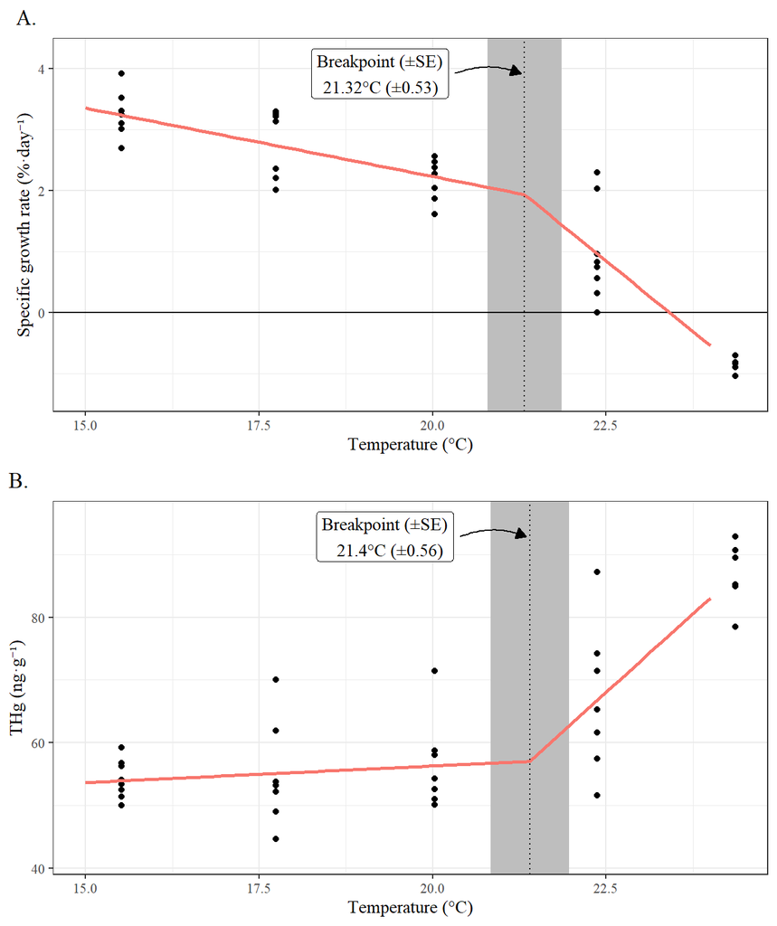

```r
(msFig2 <-
   cowplot::plot_grid(
     # Specific Growth
     lm_a1_pwise_Growth$fig +
       labs(title = "A.") +
       theme(text = element_text(family = "serif"),
             plot.title.position = "plot"),
     # Hg
     lm_a1_pwise_Hg$fig +
       labs(title = "B.") +
       theme(text = element_text(family = "serif"),
             plot.title.position = "plot"),

     nrow = 2, align = "v", axis = "l")
)
```

## 5.3 Figure 3

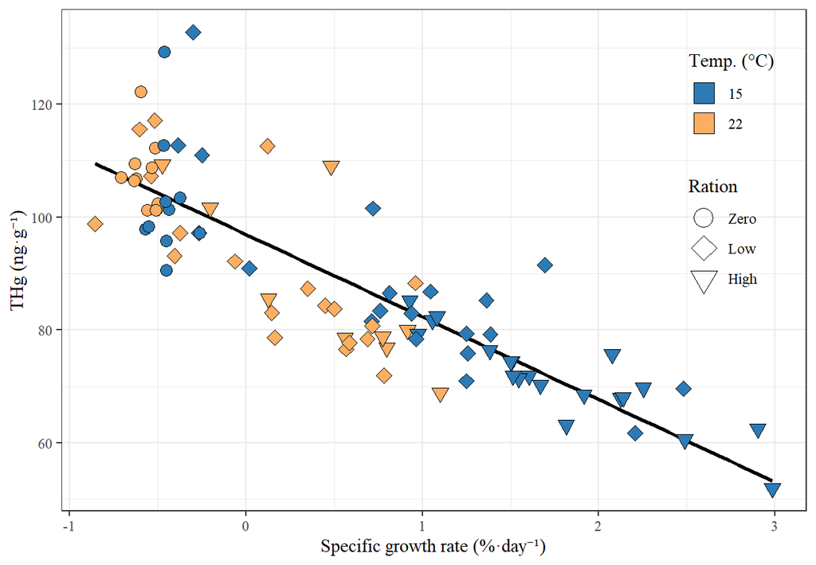

```r
(msFig3 <- ggplot(data = dat_exp2, aes(x = growth_spe, y = Hg)) +
   geom_smooth(method = "lm", formula = 'y ~ x', se = FALSE, color = "black") +
   geom_point(aes(fill = tempfac, shape = rationfac),
              size = 3) +
   theme_bw() +
   scale_shape_manual(breaks = c("Zero","Low","High"),
                      values = c(21,23,25),
                      guide = guide_legend(override.aes = list(size = 5), order = 2) ) +
   scale_fill_manual(breaks = c("15","18","20","22","24"),
                     values = temp_colors_vec,
                     guide = guide_legend(override.aes = list(shape = 22, size = 6), order = 1)) +
   theme(text = element_text(family = "serif"),

         legend.position = "inside", legend.position.inside = c(0.9,0.675),
         legend.background = element_blank(), legend.key = element_blank()) +
   labs(x = "Specific growth rate (%\u00B7day\u207B\u00B9)",
        y = "THg (ng\u00b7g\u207B\u00B9)",
        fill = "Temp. (\u00B0C)",shape = "Ration")
)
```

**Linear model fit report:**

```r
report(lm(Hg ~ growth_spe, data = dat_exp2))
```

We fitted a linear model (estimated using OLS) to predict Hg with growth_spe (formula: Hg ~ growth_spe). The model explains a statistically significant and substantial proportion of variance (R2 = 0.73, F(1, 87) = 240.21, p < .001, adj. R2 = 0.73). The model’s intercept, corresponding to growth_spe = 0, is at 96.91 (95% CI [94.80, 99.03], t(87) = 91.10, p < .001). Within this model:

- The effect of growth spe is statistically significant and negative (beta = -14.63, 95% CI [-16.50, -12.75], t(87) = -15.50, p < .001; Std. beta = -0.86, 95% CI [-0.97, -0.75])

Standardized parameters were obtained by fitting the model on a standardized version of the dataset. 95% Confidence Intervals (CIs) and p-values were computed using a Wald t-distribution approximation.

**Linear model estimate table:**

```r
report_table(lm(Hg ~ growth_spe, data = dat_exp2))
```

```
## Parameter   | Coefficient |           95% CI |  t(87) |      p | Std. Coef.
## ---------------------------------------------------------------------------
## (Intercept) |       96.91 | [ 94.80,  99.03] |  91.10 | < .001 |  -4.61e-16
## growth spe  |      -14.63 | [-16.50, -12.75] | -15.50 | < .001 |      -0.86
##             |             |                  |        |        |
## AIC         |             |                  |        |        |
## AICc        |             |                  |        |        |
## BIC         |             |                  |        |        |
## R2          |             |                  |        |        |
## R2 (adj.)   |             |                  |        |        |
## Sigma       |             |                  |        |        |
##
## Parameter   | Std. Coef. 95% CI |    Fit
## ----------------------------------------
## (Intercept) |    [-0.11,  0.11] |
## growth spe  |    [-0.97, -0.75] |
##             |                   |
## AIC         |                   | 642.76
## AICc        |                   | 643.04
## BIC         |                   | 650.22
## R2          |                   |   0.73
## R2 (adj.)   |                   |   0.73
## Sigma       |                   |   8.76
```

## 5.4 Figure 4

```r
# ANOVA model for significance letters/comparisons
fig4_mod <- aov(formula = Hg ~ tempLabels * rationfac, data = fig4_data)

# summary of ANOVA model
summary(fig4_mod) |> pander()
```

Analysis of Variance Model

|  | Df | Sum Sq | Mean Sq | F value | Pr(>F) |
| --- | --- | --- | --- | --- | --- |
| **tempLabels** | 2 | 3058 | 1529 | 9.463 | 0.0001831 |
| **rationfac** | 2 | 8789 | 4395 | 27.2 | 5.246e-10 |
| **tempLabels:rationfac** | 2 | 680.4 | 340.2 | 2.105 | 0.1276 |
| **Residuals** | 92 | 14865 | 161.6 | NA | NA |

```r
# TukeyHSD comparisons
fig4_HSD <- TukeyHSD(fig4_mod)

# model means for each grouping of temp by ration
model_means_cld <- emmeans(object = fig4_mod, specs = ~ tempLabels + rationfac)

# still Tukey pair-wise comparisons, but sidak used for CIs in output
cld <- cld(model_means_cld, adjust = "sidak",
           Letters = letters, alpha = 0.05, decreasing = TRUE)

# generate data frame for TukeyHSD significance letter labels
# These letters represent statistical significant across all treatment levels
cld_df <- data.frame(tempLabels = cld$tempLabels,
                     rationfac = cld$rationfac,
                     cld = cld$.group) |>
  filter(cld != "") |>
  left_join(select(data.frame(model_means_cld), tempLabels, rationfac, Hg = upper.CL),
            by = c("tempLabels","rationfac"))
```

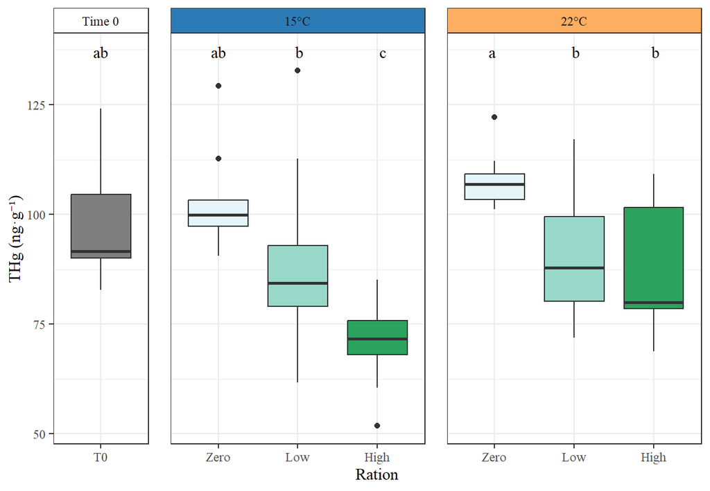

```r
strip_cols <-
  ggh4x::strip_themed(background_x = ggh4x::elem_list_rect(fill = c("white",'#2c7bb6','#fdae61')))



(msFig4 <-
    ggplot(data = fig4_data) +
    geom_boxplot(aes(x = rationfac, y = Hg, fill = rationfac)) +
    # add the statistical significance letters to the groups
    geom_text(data = cld_df, aes(x = rationfac, y = 137,label = cld),
              family = "serif") +

    theme_bw() +
    scale_fill_manual(breaks = c("","Zero","Low","High"),
                      values = c("white", "#e5f5f9", "#99d8c9", "#2ca25f")) +
    ggh4x::facet_grid2(~tempLabels,
                       space = "free",
                       strip = strip_cols,
                       scales = "free_x") +
    theme(panel.spacing = unit(1, "lines"),
          strip.background = element_rect(fill = c(NA,'#2c7bb6','#fdae61')),
          legend.position = "none",
          text = element_text(family = "serif")) +
    labs(y = "THg (ng\u00B7g\u207B\u00B9)", x = "Ration", fill = "Ration")
)
```

## 5.5 Figure 5

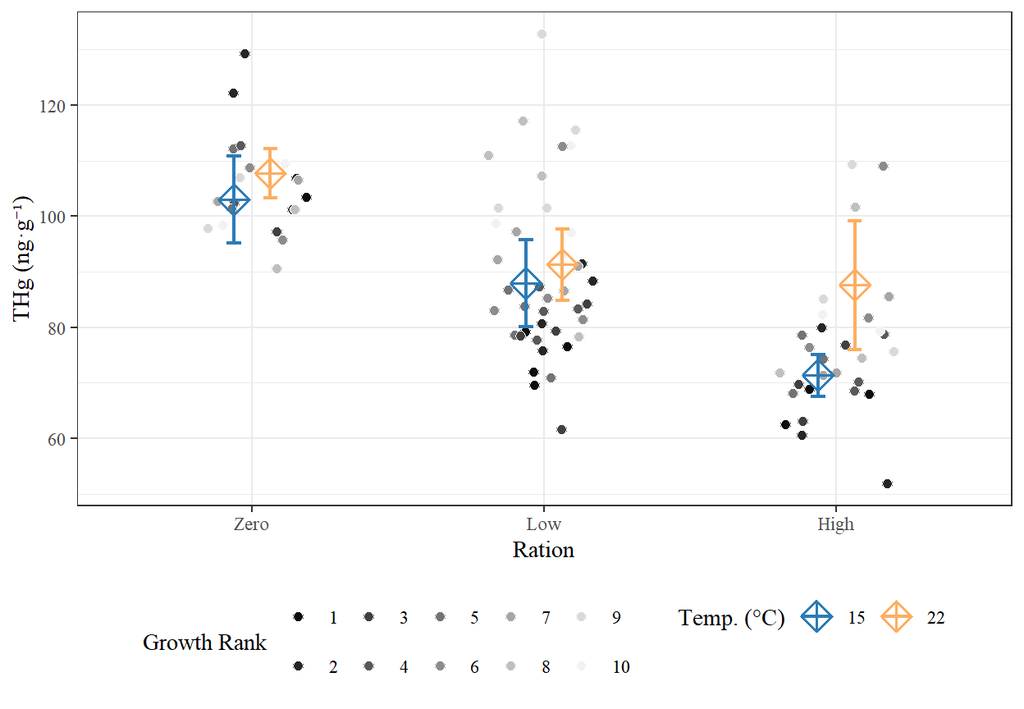

```r
(msFig5 <- ggplot(data = threeway_plot_df,
                       aes(x = rationfac, y = TheMean, color = tempfac)) +

   geom_point(data = select(dat_exp2, TheMean = Hg, rationfac, growth_abs_tnk_rnk, tempfac),
              aes(x = rationfac, y = TheMean, fill = growth_abs_tnk_rnk),
              size = 2, color = "white", shape = 21,
              position = position_jitter(seed = 1, width = 0.2)) +

   geom_errorbar(aes(ymin = LowerBoundCI, color = tempfac, ymax = UpperBoundCI),
                 width = 0.1, linewidth = 0.8, position = position_dodge(0.25)) +
   geom_point(position = position_dodge(0.25), shape = 5, size = 4, stroke = 1) +
   geom_point(position = position_dodge(0.25), shape = 3, size = 4, stroke = 1) +

   theme_bw() +
   scale_fill_manual(breaks = c(1:10),
                     values = paste0("grey",seq(5,95,length.out = 10))) +
   scale_color_manual(breaks = c("15","18","20","22","24"),
                     values = temp_colors_vec) +
   theme(text = element_text(family = "serif"),
         legend.background = element_blank(),
         legend.position = "bottom",
         legend.position.inside = c(0.8,0.95),
         legend.direction = "horizontal", legend.key = element_blank(),
         plot.caption = element_text(hjust = 0)) +
   labs(x = "Ration", y = "THg (ng\u00b7g\u207B\u00B9)",
        color = "Temp. (\u00B0C)", fill = "Growth Rank")
)
```

## 5.6 Figure 6

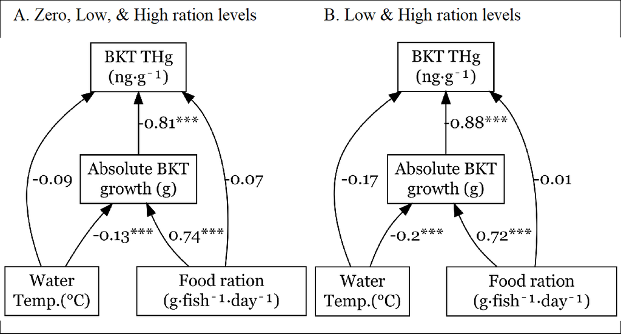

```r
# read back in each png file for each path diagram and convert to ggplot object
pd1 <-
  magick::image_read(path = "./figs/Figure6A_SEM_zero_low_high.png") |>
  magick::image_ggplot()

pd2 <-
  magick::image_read("./figs/Figure6B_SEM_low_high.png") |>
  magick::image_ggplot()

# use cowplot to arrange panel of ggplot objects
(msFig6 <-
  cowplot::plot_grid(
     # zero, low, & high
     pd1 +
       labs(title = "   A. Zero, Low, & High ration levels") +
       # labs(title = "") +
       theme(text = element_text(family = "serif"),
             plot.title.position = "plot"),
     # low & high
     pd2 +
       labs(title = "   B. Low & High ration levels") +
       # labs(title = "") +
       theme(text = element_text(family = "serif"),
             plot.title.position = "plot"),
     # number of rows in panel plot
     nrow = 1) +
  theme(plot.background = element_rect(fill = "white"))
)
```

## 5.7 Save figures to files

PNG file exports.

```r
ggsave(plot = msFig1, units = "in", width = 6.5, height = 4.5, dpi = 600,
       file = "./figs/Figure1.png")

ggsave(plot = msFig2, units = "in", width = 6.5, height = 7.75, dpi = 600,
       file = "./figs/Figure2.png")

ggsave(plot = msFig3, units = "in", width = 6.5, height = 4.5, dpi = 600,
       file = "./figs/Figure3.png")

ggsave(plot = msFig4, units = "in", width = 6.5, height = 4.5, dpi = 600,
       file = "./figs/Figure4.png")

ggsave(plot = msFig5, units = "in", width = 6.5, height = 4.5, dpi = 600,
       file = "./figs/Figure5.png")

ggsave(plot = msFig6, units = "in", width = 6.5, height = 3.5, dpi = 600,
       file = "./figs/Figure6.png")
```

EPS file exports.

```r
ggsave(plot = msFig1, units = "in", width = 6.5, height = 4.5, dpi = 600,
       device = cairo_ps,
       file = "./figs/Figure1.eps")

ggsave(plot = msFig2, units = "in", width = 6.5, height = 7.75, dpi = 600,
       device = cairo_ps,
       file = "./figs/Figure2.eps")

ggsave(plot = msFig3, units = "in", width = 6.5, height = 4.5, dpi = 600,
       device = cairo_ps,
       file = "./figs/Figure3.eps")

ggsave(plot = msFig4, units = "in", width = 6.5, height = 4.5, dpi = 600,
       device = cairo_ps,
       file = "./figs/Figure4.eps")

ggsave(plot = msFig5, units = "in", width = 6.5, height = 4.5, dpi = 600,
       device = cairo_ps,
       file = "./figs/Figure5.eps")

ggsave(plot = msFig6, units = "in", width = 6.5, height = 3.5, dpi = 600,
       device = cairo_ps,
       file = "./figs/Figure6.eps")
```